# SPRIS Proj 6

Wuraola Olawole

2026-05-05

```r
library(tidyverse)
library(dplyr)
library(readxl)
library(ggplot2)
library(readr)
library(table1)
library(knitr)
library(kableExtra)
```

## Import data

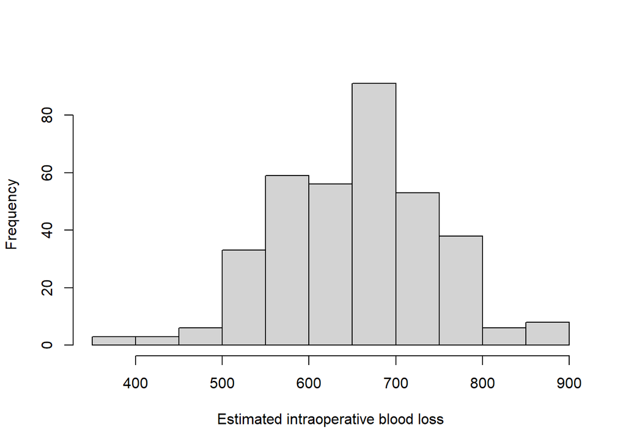

```r
################################## Pilot data #####################################

dat  <- read_csv("C:/Users/wuras/Downloads/ebl.csv") %>%
  mutate(sex = factor(sex),
         race = factor(race),
         group = factor(prot_energy))


#summary(dat)

hist(dat$ebl,
     main ="",
     xlab ="Estimated intraoperative blood loss")
```

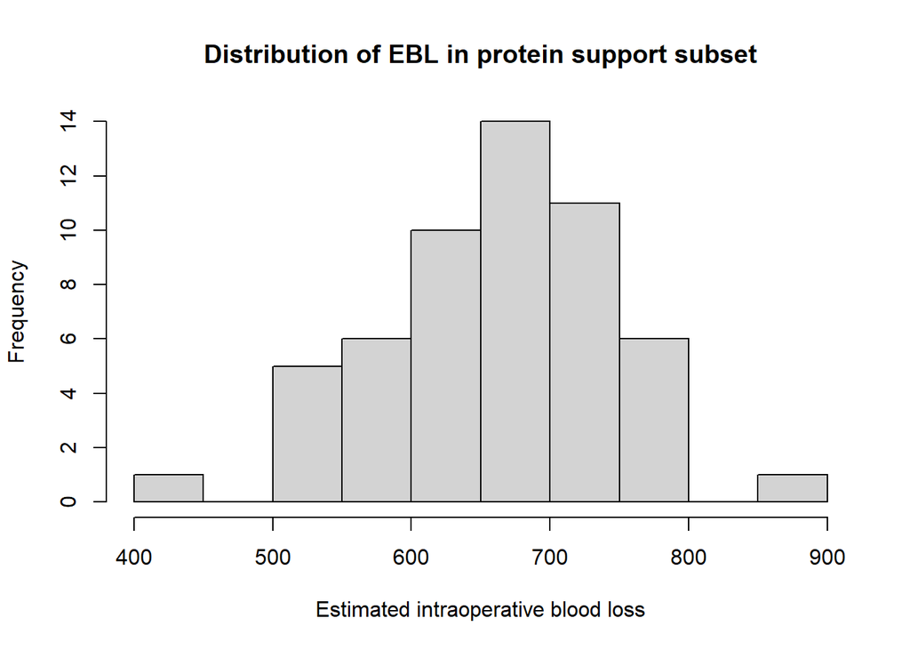

```r
## Among subset data for protein support
dat2 <- dat %>% filter(is.na(group)==FALSE)

hist(dat2$ebl,
     main ="Distribution of EBL in protein support subset",
     xlab ="Estimated intraoperative blood loss")
```

```r
## Pilot model for sample size calculation
model <- lm(ebl ~ group + age + sex + race, data = dat)

mod_sum <- summary(model)

rse <- mod_sum$sigma          # Residual Standard Error
r_sq <- mod_sum$r.squared     # Multiple R-Squared
```

## Sample Size Calculation for the Future Observational study

The goal is to demonstrate that adequate protein energy support ($\mu_{adq}$) is better at reducing blood loss by average of at least 40mL compared to the inadequate protein energy support ($\mu_{inadq}$).

**The hypothesis for the study is given as:**

The Null Hypothesis ($H_0$):
$$H_0: \mu_{inadq} - \mu_{adq} \leq 0$$

The Alternative Hypothesis ($H_a$):
$$H_a:
\mu_{inadq} - \mu_{adq} > 0$$

Where:

- $\mu_{inadq}$: Mean ebl of inadequate protein energy support group
- $\mu_{adq}$: Mean ebl of adequate protein energy support group
- $\delta$: MCID

However, we wish to adjust for known confounding factors, Age, Sex, and Race. Therefore, using the pilot model:

$$Y_{ebl}= \beta_0 + \beta_1 Group +
\beta_2 Age + \beta_3 Sex + \beta_4 Race + \epsilon$$
,

**The hypothesis becomes:**

The Null Hypothesis ($H_0$):
$$H_0: \beta_1 \geq 0$$

The Alternative Hypothesis ($H_a$):
$$H_a:
\beta_1 < 0$$

To prove clinical meaningfulness, the upper bound 95% CI must be < -$\delta$

For the sample size calculation, let

- MCID, $\delta$ = 40mL
- type I error rate, $\alpha$ = 5%
- power, $1-\beta$ = 80%
- RSE from pilot model, $\sigma$ = 91.56
- R-square from pilot model, $R^2$ = 0.088
- Dropout rate, $d$ = 20%

Accounting for dropout rate the final n per arm becomes:

$$n_{final} = \frac{n_0}{(1 - d )}$$

```r
# Inputs
alpha <- 0.05   # Bonferroni adjustment
power <- 0.80
delta <- 40
d <- 0.20
sigma <- 91.56
r_sq <- 0.088

z_alpha <- qnorm(1 - alpha/2)
z_beta <- qnorm(power)

n0_per_arm <- (2 * (z_alpha + z_beta)^2 * sigma^2)/ ((1-r_sq^2)*delta^2)

n_final_per_arm <- n0_per_arm/(1-d)
```